DS 6030 | Fall 2024 | University of Virginia

# Homework #5: Probability and Classification

Author

**SOLUTIONS**

Published

Fall 2024

**Warning**

These solutions are only for the private use of the students of DS 6030 Fall 2024. Sharing of the solutions, posting on the internet, selling to a company, or possession by anyone outside of the class constitutes a violation of the honor policy.

# Required R packages and Directories

```r
dir_data= 'https://mdporter.github.io/teaching/data/' # data directory
library(glmnet)
library(ranger)
library(tidymodels)
library(tidyverse) # functions for data manipulation
```

# Crime Linkage

Crime linkage attempts to determine if a set of unsolved crimes share a common offender. *Pairwise* crime linkage is the more simple task of deciding if two crimes share a common offender; it can be considered a binary classification problem. The linkage training data has 8 evidence variables that measure the similarity between a pair of crimes:

- `spatial` is the spatial distance between the crimes
- `temporal` is the fractional time (in days) between the crimes
- `tod` and `dow` are the differences in time of day and day of week between the crimes
- `LOC`, `POA,` and `MOA` are binary with a 1 corresponding to a match (type of property, point of entry, method of entry)
- `TIMERANGE` is the time between the earliest and latest possible times the crime could have occurred (because the victim was away from the house during the crime).
- The response variable indicates if the crimes are linked ($y=1$) or unlinked ($y=0$).

These problems use the [linkage-train](https://mdporter.github.io/teaching/data//linkage_train.csv) and [linkage-test](https://mdporter.github.io/teaching/data//linkage_test.csv) datasets (click on links for data).

## Load Crime Linkage Data

**Solution**

```r
train = read_csv(file.path(dir_data, "linkage_train.csv"))
test =  read_csv(file.path(dir_data, "linkage_test.csv"))
```

# Problem 1: Penalized Regression for Crime Linkage

## a. Fit a penalized *linear regression* model to predict linkage.

Use an elastic net penalty (including lasso and ridge) (your choice).

- Report the value of $\alpha \in [0, 1]$ used.
- Report the value of $\lambda$ used.
- Report the estimated coefficients.

**Solution**

```r
library(glmnet)

#: Format data
X.train = glmnet::makeX(select(train, -y)) # make X matrix
Y.train = train$y                          # make Y vector
```

```r
#: Fit elastic net using cross-validation
alpha = .8        # used alpha=.8 (just picked it)
set.seed(2020)    # controls cv folds
lin_reg = cv.glmnet(x = X.train, y=Y.train, alpha=alpha)

#: optimal lambda values
(lambda.hat = lin_reg$lambda.min)
```

```
[1] 0.00011
```

```r
#: coefficients
coef(lin_reg, s="lambda.min") |> round(4)
```

```
9 x 1 sparse Matrix of class "dgCMatrix"
                 s1
(Intercept)  0.0935
spatial     -0.0024
temporal    -0.0002
tod         -0.0022
dow         -0.0058
LOC          0.0431
POA          0.0093
MOA          0.0072
TIMERANGE    0.0000
```

## b. Fit a penalized *logistic regression* model to predict linkage.

Use an elastic net penalty (including lasso and ridge) (your choice).

- Report the value of $\alpha \in [0, 1]$ used.
- Report the value of $\lambda$ used.
- Report the estimated coefficients.

**Solution**

```r
library(glmnet)

#: Fit elastic net using cross-validation
alpha = .8        # used alpha=.8 (just picked it)
set.seed(2020)    # controls cv folds
log_reg = cv.glmnet(x = X.train, y=Y.train, alpha=alpha,
                 family="binomial")

#: optimal lambda values
(lambda.hat = log_reg$lambda.min)
```

```
[1] 7.55e-05
```

```r
#: coefficients
coef(log_reg, s="lambda.min") |> round(4)
```

```
9 x 1 sparse Matrix of class "dgCMatrix"
                 s1
(Intercept) -0.0351
spatial     -0.2856
temporal    -0.0124
tod         -0.1126
dow         -0.2380
LOC          1.3867
POA          0.4386
MOA          0.2081
TIMERANGE    0.0006
```

# Problem 2: Random Forest for Crime Linkage

Fit a random forest model to predict crime linkage.

- Report the loss function (or splitting rule) used.
- Report any non-default tuning parameters.
- Report the variable importance (indicate which importance method was used).

**Solution**

Using the `ranger` package for speed. I’m going to tune the `mtry` variable using the out-of-bag estimated loss. This is a function that fits the random forest and returns the oob error. The help (`?ranger`) tells use that the brier score is used for the oob error (when probability trees are grown).

```r
library(ranger)

rf_fit <- function(x, y, mtry = 1, ...){
  # fit the ranger model
  rf =
    ranger(x = as.matrix(x), y = y,
      mtry = mtry,         # this is the tuning parameters
      num.trees = 2000,    # set number of trees large
      probability = TRUE,  # allows probability outputs,
      min.node.size = 1,   # allows only single obs in leaf
      splitrule = "gini",  # there aren't many options
      num.threads = 6,     # use multiple cores to speed up
      seed = 2024,         # set seed
      ...     # any extra arguments passed into ...
      )
  # get the oob error
  perf = tibble(mtry = mtry, oob_error = rf$prediction.error)
  # return a list of the ranger object and performance
  list(rf = rf, perf = perf)
}
```

Now I’ll search over `mtry` values to find the best oob performance.

```r
library(purrr)

#: set tuning grids
tune_pars = tibble(mtry = 1:8)

#: search over all tuning parameters
rf_tune =
  tune_pars$mtry |>
  map(\(m) rf_fit(x = train |> select(-y), y = train$y, mtry = m)$perf) |>
  bind_rows()
```

```r
rf_tune |>
  arrange(oob_error)
```

```
# A tibble: 8 × 2
   mtry oob_error
  <int>     <dbl>
1     2   0.00852
2     3   0.00854
3     4   0.00861
4     5   0.00868
5     6   0.00876
6     7   0.00881
# ℹ 2 more rows
```

```r
best_tune = rf_tune |> slice_min(oob_error)
```

Now that we have our best tuning parameters, I’ll fit a final model using the optimal tuning parameter. I’ll also tell ranger to compute importance. I turned it off during tuning because it can slow things down.

```r
rf_final =
  rf_fit(
    x = train |> select(-y), y = train$y,
    mtry = best_tune$mtry,
    importance = "impurity"
  )$rf
```

```r
rf_final$variable.importance |>
  enframe(name = "variable", value = "importance") |>
  arrange(-importance)
```

```
# A tibble: 8 × 2
  variable  importance
  <chr>          <dbl>
1 spatial        390.
2 temporal       206.
3 tod             92.3
4 dow             90.2
5 TIMERANGE       71.9
6 LOC             21.6
# ℹ 2 more rows
```

# Problem 3: ROC Curves

## a. ROC curve: training data

Produce one plot that has the ROC curves, using the *training data*, for all three models (linear, logistic, and random forest). Use color and/or linetype to distinguish between models and include a legend.  
Also report the AUC (area under the ROC curve) for each model. Again, use the *training data*.

- Note: you should be weary of being asked to evaluation predictive performance from the same data used to estimate the tuning and model parameters. The next problem will walk you through a more proper way of evaluating predictive performance with resampling.

**Solution**

We have estimated the tuning parameters using resampling, so while we are somewhat protected against strong over-fitting, we should still be wary that the ROC curves may reflect a more optimistic view of what we would see if we created the ROC curves with test data.

```r
library(yardstick)

#: get predictions
pred_data =
  tibble(
    linear = predict(lin_reg, X.train, s="lambda.min")[,1],
    logistic = predict(log_reg, X.train, s="lambda.min",
                       type="response")[,1],
    rf = predict(rf_final, train)$predictions[,1],
    linked = Y.train |> factor(levels=c(1,0)) # note: outcome must be a factor
  )  |>
  # convert to long format
  pivot_longer(
    c(linear, logistic, rf),
    names_to = "model",
    values_to = "prediction"
  )

# get performance for each model
pred_data |>
  group_by(model) |>
  roc_curve(truth = linked, prediction)          # get ROC curve data
```

```
# A tibble: 89,970 × 4
# Groups:   model [3]
  model  .threshold specificity sensitivity
  <chr>       <dbl>       <dbl>       <dbl>
1 linear  -Inf        0                   1
2 linear    -0.121    0                   1
3 linear    -0.104    0.0000339           1
4 linear    -0.103    0.0000678           1
5 linear    -0.101    0.000102            1
6 linear    -0.0993   0.000136            1
# ℹ 89,964 more rows
```

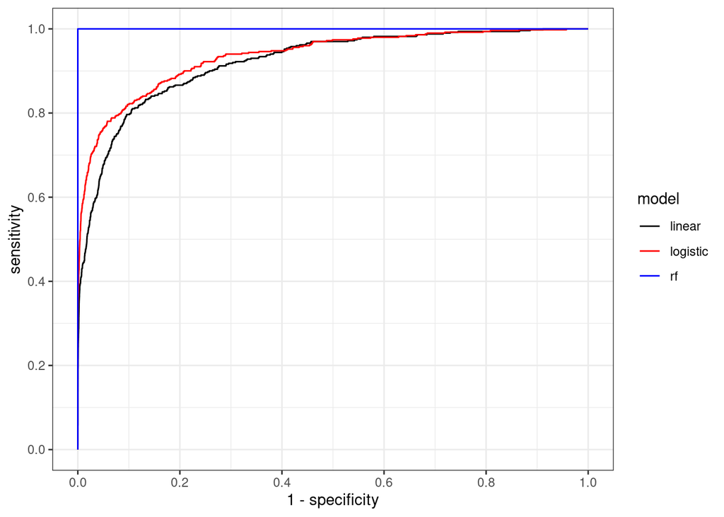

```r
#: plot ROC curve
pred_data |>
  group_by(model) |>
  roc_curve(truth = linked, prediction) |>
  ggplot(aes(1-specificity, sensitivity, color=model)) +
  geom_path() +
  scale_color_manual(values=c(linear='black', logistic='red', rf="blue")) +
  scale_x_continuous(breaks=seq(0, 1, by=.2)) +
  scale_y_continuous(breaks=seq(0, 1, by=.2))
```

```r
pred_data |>
  group_by(model) |>
  roc_auc(truth = linked, prediction)
```

```
# A tibble: 3 × 4
  model    .metric .estimator .estimate
  <chr>    <chr>   <chr>          <dbl>
1 linear   roc_auc binary         0.921
2 logistic roc_auc binary         0.935
3 rf       roc_auc binary         1
```

It appears the logistic regression model has better classification performance across many thresholds (since the logistic curve is almost everywhere better than the linear.)

The random forest (RF) model predicting the training data looks about perfect. This is not surprising when you think about what we implemented. The RF model used in-bag data to grow fully deep trees with just a single observation in each leaf node. These will obviously be perfectly predicting the in-bag data, but perhaps not perfect for the out of bag. The oob error calculations are based only on the trees which had the observation out of bag. But here, we are making predictions from all trees in the forest. So the overfit individual trees are having a pronounced influence on the predictions used to calculate the *training* ROC.

In summary, the *training* ROC curves for linear and logistic may not be too far from what we would expect with *testing* data, but the RF forest is not realistic.

## b. ROC curve: resampling estimate

Recreate the ROC curve from the penalized logistic regression (logreg) and random forest (rf) models using repeated hold-out data. The following steps will guide you:

- For logreg, use $\alpha=.75$. For rf use *mtry = 2*, *num.trees = 1000*, and fix any other tuning parameters at your choice.
- Run the following steps 25 times:
  1. Hold out 500 observations.
  2. Use the remaining observations to estimate $\lambda$ using 10-fold CV for the logreg model. Don’t tune any rf parameters.
  3. Predict the probability of linkage for the 500 hold-out observations.
  4. Store the predictions and hold-out labels.
  5. Calculate the AUC.
- Report the mean AUC and standard error for both models. Compare to the results from part a.
- Produce two plots showing the 25 ROC curves for each model.
- Note: by estimating $\lambda$ each iteration, we are incorporating the uncertainty present in estimating that tuning parameter.

**Solution**

First I’m going to make functions to fit each model to the training data, make predictions on the test data, and save the required output.

```r
library(ranger)
rf_wf <- function(data_train, data_test, ...){
  # fit the ranger model
  rf =
    ranger(y~., data = data_train |> mutate(y = factor(y, c(1,0))),
      mtry = 2,            # this is the tuning parameters
      num.trees = 1000,    # set number of trees large
      probability = TRUE,  # allows probability outputs,
      min.node.size = 1,   # allows only single obs in leaf
      splitrule = "gini",  # there aren't many options
      num.threads = 6,     # use multiple cores to speed up
      seed = 2024,         # set seed
      ...     # any extra arguments passed into ...
      )
  # predict on the test data
  tibble(
    y = data_test$y |> factor(c(1,0)),
    p_hat = predict(rf, data_test)$predictions[,1]
  )
}
```

```r
library(glmnet)
logreg_wf <- function(data_train, data_test, seed = NULL, ...){
  # convert data to matrices
  X = glmnet::makeX(
    train = data_train |> select(-y),
    test = data_test |> select(-y)
  )
  # estimate lambda using 10 fold cv
  if(!is.null(seed) && is.numeric(seed)) set.seed(seed)
  enet =
    cv.glmnet(x = X$x, y = data_train$y,
           family = "binomial",
           alapha = 0.75,
           nfolds = 10,
           ...)
  # predict on the test data
  tibble(
    y = data_test$y |> factor(c(1,0)),
    p_hat = predict(enet, X$xtest,
                    s = "lambda.min", type = "response")[,1]
  )
}
```

Here, we run the resampling

```r
#: Settings
n = nrow(train)    # size of training data
n_repeats = 25     # number of times to repeat hold-out
n_hout = 500       # hold out size

#: Run iterations
results = vector("list", n_repeats)
for(m in 1:n_repeats){
  set.seed(m)
  hout = sample(n, size=n_hout)   # indices to hold-out
  logreg = logreg_wf(train[-hout,], train[hout,], seed = 2024)
  rf = rf_wf(train[-hout,], train[hout,])
  #- Store results
  results[[m]] = bind_rows(logreg=logreg, rf=rf, .id = "model")
}

results = bind_rows(results, .id = "iter")
```

And calculating the AUC values and summaries:

```r
AUC = results |>
  group_by(model, iter) |>
  roc_auc(y, p_hat)

AUC |>
  summarize(.by = model,
    n_iters = n(),
    auc_avg = mean(.estimate),
    auc_sd = sd(.estimate),
    auc_se = auc_sd / sqrt(n_iters)
  )
```

```
# A tibble: 2 × 5
  model  n_iters auc_avg auc_sd auc_se
  <chr>    <int>   <dbl>  <dbl>  <dbl>
1 logreg      25   0.925 0.0536 0.0107
2 rf          25   0.918 0.0592 0.0118
```

And producing the ROC curves

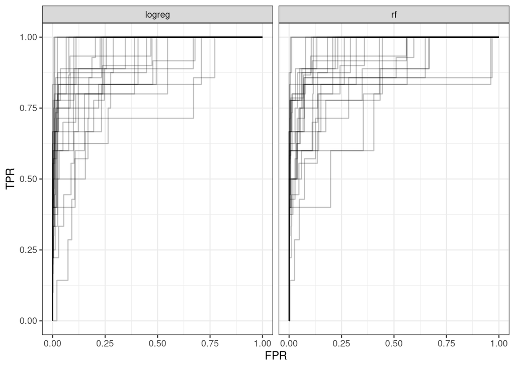

```r
#: Make ROC Curve
ROC = results |>
  group_by(model, iter) |>
  roc_curve(y, p_hat) |>
  mutate(
    FPR = 1-specificity,
    TPR = sensitivity
  )

ROC |>
  arrange(.threshold) |>
  ggplot(aes(FPR, TPR, group = iter)) +
  geom_path(alpha = .25) +
  facet_wrap(~model)
```

The hold-out performance is similar to what was estimated using the training data for the logistic regression. But notice how the random forest performance came way down. For deep trees, you should never assess on the training data but use only oob or out of sample data for assessment).

# Problem 4: Contest

## a. Contest Part 1: Predict the estimated *probability* of linkage.

Predict the estimated *probability* of linkage for the test data (using any model).

- Submit a .csv file (ensure comma separated format) named `lastname_firstname_1.csv` that includes the column named **p** that is your estimated posterior probability. We will use automated evaluation, so the format must be exact.
- You are free to any model (even ones we haven’t yet covered in the course).
- You are free to use any data transformation or feature engineering.
- You will receive credit for a proper submission; the top five scores will receive 2 bonus points.
- Your probabilities will be evaluated with respect to the mean negative Bernoulli log-likelihood (known as the average *log-loss* metric):
  $$L = - \frac{1}{M} \sum_{i=1}^m [y_i \log \, \hat{p}_i + (1 - y_i) \log \, (1 - \hat{p}_i)]$$
  where $M$ is the number of test observations, $\hat{p}_i$ is the prediction for the $i$th test observation, and $y_i \in \{0,1\}$ are the true test set labels.

**Solution**

I decided to use the elasticnet *logistic* regression model for the contest.

```r
library(glmnet)
library(tidyverse)

#: Pre-process data
X = glmnet::makeX(select(train, -y), test)

#: Fit elastic net using cross-validation
alpha = .8        # used alpha=.8 (just picked it)
set.seed(2020)    # controls cv folds
log_reg = cv.glmnet(x = X$x, y=train$y,
                    alpha=alpha,
                    family="binomial")
```

```r
#: Use the logistic regression model to make predictions on test data
yhat = predict(log_reg, X$xtest, s="lambda.min", type="response")[,1] # convert to vector

#: Calculate the log-loss
Y.test = read_csv("../data/linkage_testsoln.csv") |> pull()
(logL = yardstick::mn_log_loss_vec(factor(Y.test, c(1,0)), yhat))
```

```
[1] 0.0453
```

This gives an $-\log L = 0.045$. Did you beat me?

## b. Contest Part 2: Predict the *linkage label*.

Predict the linkages for the test data (using any model).

- Submit a .csv file (ensure comma separated format) named `lastname_firstname_2.csv` that includes the column named **linkage** that takes the value of 1 for linked pairs and 0 for unlinked pairs. We will use automated evaluation, so the format must be exact.
- You are free to any model (even ones we haven’t yet covered in the course).
- You are free to use any data transformation or feature engineering.
- Your labels will be evaluated based on total cost, where cost is equal to `1*FP + 8*FN`. This implies that False Negatives (FN) are 8 times as costly as False Positives (FP).
- You will receive credit for a proper submission; the top five scores will receive 2 bonus points. Note: you only will get bonus credit for one of the two contests.

**Solution**

I am going to re-estimate the tuning parameters to optimize the special cost metric. Note that model parameters are still estimated using negative log-likelihood (log-loss), but hopefully they will lead to good performance of the cost metric.

Theoretically, the optimal threshold (for $\gamma(x)$) is $\log \frac{FP}{FN} = -2.08$, but I will search over a range of thresholds in case the $\gamma$ values are biased.

```r
#: Settings
n_holdout = 500   # number of hold-out obs
n_repeats = 50    # number of times repeated
alpha.seq = seq(0, 1, length=5)  # alpha sequence to search over
n = nrow(train) # size of training data
thresholds = c(seq(1.25*log(1/8), 0.75*log(1/8), length=6), log(1/8)) |>
  unique() |> sort()

#: Cost Function (total cost)
#  Note: G.hat can be a matrix or vector (binary or logical)
#        truth is a binary vector (binary or logical)
cost_function <- function(G.hat, truth){
  G.hat = as.matrix(G.hat)
  FP = crossprod(G.hat == 1, truth == 0) # FP = sum(G.hat == 1 & truth == 0)
  FN = crossprod(G.hat == 0, truth == 1) # FN = sum(G.hat == 0 & truth == 1)
  as.vector(FP + 8*FN)
}

#: Specify lambda sequence. Note: the lambda sequence is a function of alpha.
#  so I will combine lambdas from the extremes, ridge and lasso.
#  Ensure decreasing lambda values! This isn't causing data leakage because
#  only using the data to get range of plausible lambda values
lam_seq = c(glmnet(X$x, train$y, alpha=0, family="binomial")$lambda,
            glmnet(X$x, train$y, alpha=1, family="binomial")$lambda) |>
  unique() |>
  sort(decreasing=TRUE)


#: Search performance over tuning parameters
set.seed(2020)
C = tibble()
for(m in 1:n_repeats){

  hout = sample(n, size=n_holdout)   # indices to hold-out

  for(a in alpha.seq){

    #- estimate model parameters (for sequence of lambda)
    fit = glmnet(x = X$x[-hout,], y=train$y[-hout],
                 alpha=a,
                 family="binomial",
                 lambda = lam_seq)

    #- make predictions for all lambda values
    pred = predict(fit, X$x[hout,], s = lam_seq, type="link")

    #- get cost for all predictions
    for(thres in thresholds){
      cost = cost_function(pred >= thres, train$y[hout])
      out = tibble(
        alpha = a,
        threshold = thres,
        lambda = lam_seq,
        cost = cost,
        iter = m
      )
      C = bind_rows(C, out)
    }
  }
}

C
```

```
# A tibble: 281,750 × 5
  alpha threshold lambda  cost  iter
  <dbl>     <dbl>  <dbl> <dbl> <int>
1     0     -2.60   23.3    40     1
2     0     -2.60   21.2    40     1
3     0     -2.60   19.3    40     1
4     0     -2.60   17.6    40     1
5     0     -2.60   16.0    40     1
6     0     -2.60   14.6    40     1
# ℹ 281,744 more rows
```

```r
#: select the tuning parameters that minimize cost
opt.tune = C |>
  group_by(lambda, alpha, threshold) |>
    summarize(avg_cost = mean(cost), n=n()) |>
  ungroup() |>
  arrange(avg_cost, -lambda) |>
  slice(1)   # choose 1, even if ties

opt.tune  # print results
```

```
# A tibble: 1 × 5
   lambda alpha threshold avg_cost     n
    <dbl> <dbl>     <dbl>    <dbl> <int>
1 0.00280     1     -1.98     27.4    50
```

```r
#: Make predictions on test set
#   Note:  fit with entire lam_seq (more efficient), but predict with desired lambda
fit_opt = glmnet(x = X$x, y=train$y,
                 family="binomial",
                 alpha = opt.tune$alpha,
                 lambda = lam_seq)
pred = predict(fit_opt, X$xtest, s=opt.tune$lambda, type="link")[,1]
G.hat = tibble(g = ifelse(pred >= opt.tune$threshold, 1, 0))

#: Output
# write_csv(G.hat, path = "hw5/porter_michael_2.csv") # make csv in proper format
cost_function(G.hat$g, Y.test)   # my cost
```

```
[1] 1863
```

My approach had a total cost of 1863. Did you beat me?